# Modeling Master Control

Author

Josh, Joel, Corinn, Gaby

Published

February 28, 2026

# Introduction

This notebook builds an initial model to help identify which MX leads are more likely to be successful. Using the cleaned dataset from the EDA phase, the goal is to better understand which lead characteristics are associated with progression to SQL, SQO, or Won, so Marketing and Sales can target higher potential leads more effectively.

### Load Data

In this section, we load the cleaned modeling-ready dataset,`leads_cleaned_final.rds` that was created during the EDA phase. This gives us a consistent starting point for modeling and allows the notebook to focus on prediction without repeating all of the earlier data cleaning steps.

# Create Modeling Dataset

In this section, we prepare the final dataset that will be used for modeling. Because the business problem is focused on MX targeting, we keep only MX leads, remove fields that should not be used as predictors, and make sure the target variable is labeled clearly for interpretation.

```r
# Keep MX leads only and remove IDs + original outcome
mx_model_data <- leads_cleaned_final %>%
  filter(solution_rollup == "Mx") %>%
  select(-qal_id, -contact_lead_id, -next_stage_c)

# Drop leftover duplicate column if present
if ("solution.1" %in% names(mx_model_data)) {
  mx_model_data <- mx_model_data %>%
    select(-solution.1)
}

# Relabel target for readability
mx_model_data <- mx_model_data %>%
  mutate(
    next_stage_target = factor(
      next_stage_target,
      levels = c("0", "1"),
      labels = c("Not Successful", "Successful")
    )
  )

# Quick checks
dim(mx_model_data)
```

```
[1] 4125  376
```

```r
count(mx_model_data, next_stage_target)
```

```
  next_stage_target    n
1    Not Successful 3592
2        Successful  533
```

```r
"solution.1" %in% names(mx_model_data)
```

```
[1] FALSE
```

### Interpretation of Output

The modeling dataset now includes only **MX leads**, since that is the product line this project is focused on. After removing ID fields, the original outcome column, and the leftover duplicate column, the final MX modeling dataset contains 4,125 rows and 376 columns.

The target variable is also clearly imbalanced. Out of the 4,125 MX leads, 3,592 were not successful and 533 were successful, where successful means the lead progressed to **SQL, SQO, or Won**. This means only about **12.9%** of MX leads reached a successful outcome.

From a business perspective, this tells us that successful MX leads are relatively uncommon, which is consistent with what we found in the EDA. For the marketing team, this is important because it confirms that the current pool of MX leads contains many more low converting leads than high converting ones. Because of that, the goal of modeling is not just to predict the majority group, but to help identify the smaller group of leads with a higher chance of success so targeting can be improved.

# Train/Test Split

The next step is to split the MX dataset into a training set and a test set. The training set will be used to build the model, and the test set will be used later to check how well the model performs on new data. We use a 70/30 split, and we keep the success rate similar in both groups so the comparison is fair.

```r
# Create 70/30 train/test split while keeping target balance similar
set.seed(123)

# Create split index
split_index <- createDataPartition(
  y = mx_model_data$next_stage_target,
  p = 0.70,
  list = FALSE
)

# Create training and test datasets
mx_training_data <- mx_model_data[split_index, ]
mx_test_data <- mx_model_data[-split_index, ]

# Quick checks
dim(mx_training_data)
```

```
[1] 2889  376
```

```r
dim(mx_test_data)
```

```
[1] 1236  376
```

```r
# Class balance by dataset
bind_rows(
  mx_training_data %>% mutate(dataset = "Training Set"),
  mx_test_data %>% mutate(dataset = "Test Set")
) %>%
  count(dataset, next_stage_target)
```

```
       dataset next_stage_target    n
1     Test Set    Not Successful 1077
2     Test Set        Successful  159
3 Training Set    Not Successful 2515
4 Training Set        Successful  374
```

### Interpretation of Output

The MX dataset was successfully split into a training set with 2,889 rows and a test set with 1,236 rows, which matches the intended 70/30 split. This gives us one dataset to build the model and another separate dataset to evaluate how well the model performs on data it has not seen before.

The balance of successful and not successful leads stayed very similar in both groups. In the training set, 2,515 leads were not successful and 374 were successful, while in the test set, 1,077 leads were not successful and 159 were successful. This is important because it means both datasets reflect the same overall success pattern, giving us a fairer and more reliable way to evaluate whether the model can help identify higher-potential MX leads.

# Performance Benchmark

For this project, a useful model should perform better than random guessing and should show a meaningful ability to separate higher-potential MX leads from lower-potential ones. Because the target variable is imbalanced, ROC AUC is one of the most important benchmark metrics. As an initial guideline, a model with ROC AUC around 0.70 or higher would suggest that the model is capturing useful predictive signal.

At the same time, business usefulness also matters. Even if the model is not perfect, it can still be valuable if it helps Marketing and Sales better prioritize leads that are more likely to progress to SQL, SQO, or Won compared with the current untargeted approach

# Modeling

## Baseline Model

In this section, we build a baseline model using logistic regression. This gives us a simple starting point for predicting whether an MX lead will be successful. Starting with a baseline model is helpful because it gives us an initial benchmark that stronger models can later be compared against.

For this project, logistic regression is a good first choice because it is easier to interpret than more complex models. Since the business goal is to understand which lead characteristics, such as job title and industry, are associated with higher conversion, a baseline model helps us begin answering that question in a way that is still understandable for the business team.

```r
# Create cross-validation folds on the training data
set.seed(123)

mx_folds <- vfold_cv(
  mx_training_data,
  v = 5,
  strata = next_stage_target
)

# Create recipe for preprocessing
mx_recipe <- recipe(next_stage_target ~ ., data = mx_training_data) %>%
  step_rm(contact_lead_title) %>%
  step_novel(all_nominal_predictors()) %>%
  step_other(all_nominal_predictors(), threshold = 0.01) %>%
  step_dummy(all_nominal_predictors()) %>%
  step_zv(all_predictors())

# Define logistic regression model
mx_log_model <- logistic_reg() %>%
  set_engine("glm") %>%
  set_mode("classification")

# Build workflow
mx_log_workflow <- workflow() %>%
  add_recipe(mx_recipe) %>%
  add_model(mx_log_model)

# Fit model with cross-validation
mx_log_results <- fit_resamples(
  mx_log_workflow,
  resamples = mx_folds,
  metrics = metric_set(
    yardstick::roc_auc,
    yardstick::accuracy,
    yardstick::precision,
    yardstick::recall,
    yardstick::f_meas
  )
)

# View performance metrics
collect_metrics(mx_log_results)
```

```
# A tibble: 5 × 6
  .metric   .estimator  mean     n std_err .config
  <chr>     <chr>      <dbl> <int>   <dbl> <chr>
1 accuracy  binary     0.860     5 0.00294 pre0_mod0_post0
2 f_meas    binary     0.920     5 0.00188 pre0_mod0_post0
3 precision binary     0.912     5 0.00176 pre0_mod0_post0
4 recall    binary     0.929     5 0.00480 pre0_mod0_post0
5 roc_auc   binary     0.751     5 0.0151  pre0_mod0_post0
```

### Interpretation of the output

The baseline logistic regression model ran successfully and produced an initial set of performance metrics using 5-fold cross-validation on the training data. The model achieved an accuracy of 0.8598 and a ROC AUC of 0.75. While the accuracy is fairly high, the ROC AUC is especially important here because the target variable is imbalanced. A **ROC AUC of about 0.75** suggests the model has a reasonable ability to distinguish between leads that are more likely to be successful and those that are not.

The model also produced high values for precision, recall, and F1 score, but these should be interpreted with caution because the dataset contains many predictors and some overlap between them. The remaining warnings suggest that the logistic regression model is still somewhat unstable, which is not unusual for a first baseline model with a wide dataset. Even so, this model gives us a useful starting benchmark and shows that the data contains predictive signal that can be improved in later modeling steps.

#### Model Evaluation LR

At this stage, the baseline logistic regression model is evaluated using cross-validation results from the training data only. The test set is intentionally not used yet, because it should be saved for the final selected model. This helps ensure that the final performance estimate is based on data the model has not influenced during development.

The baseline model achieved a ROC AUC of 0.75, which is above the initial benchmark of around 0.70 and suggests that the model is capturing useful predictive signal. This means the dataset appears to contain information that can help separate higher-potential MX leads from lower-potential ones. At the same time, the remaining warnings suggest that logistic regression may not be the most stable final model for this dataset, so this baseline should be treated as a benchmark that later models can be compared against.

## Decision Tree

In this section, a decision tree model is used as a second approach to predict MX lead success. Unlike logistic regression, a decision tree can capture nonlinear patterns and interactions more naturally, while also producing simpler rules that are easier to explain to a business audience.

This is especially useful for this project because the goal is not only to predict success, but also to better understand which types of leads should be prioritized. A decision tree can help translate the data into more practical decision rules around variables such as industry, enrichment quality, and title-related signals.

```r
# Create decision tree model
mx_tree_model <- decision_tree(
  cost_complexity = tune(),
  tree_depth = tune(),
  min_n = tune()
) %>%
  set_engine("rpart") %>%
  set_mode("classification")

# Build workflow
mx_tree_workflow <- workflow() %>%
  add_recipe(mx_recipe) %>%
  add_model(mx_tree_model)

# Create tuning grid
mx_tree_grid <- grid_regular(
  cost_complexity(),
  tree_depth(),
  min_n(),
  levels = 3
)

# Tune decision tree with cross-validation
set.seed(123)

mx_tree_results <- tune_grid(
  mx_tree_workflow,
  resamples = mx_folds,
  grid = mx_tree_grid,
  metrics = metric_set(
    yardstick::roc_auc,
    yardstick::accuracy,
    yardstick::precision,
    yardstick::recall,
    yardstick::f_meas
  )
)

# Show top-performing tree models based on ROC AUC
show_best(mx_tree_results, metric = "roc_auc")
```

```
# A tibble: 5 × 9
  cost_complexity tree_depth min_n .metric .estimator  mean     n std_err
            <dbl>      <int> <int> <chr>   <chr>      <dbl> <int>   <dbl>
1    0.0000000001          8    21 roc_auc binary     0.822     5 0.00874
2    0.00000316            8    21 roc_auc binary     0.822     5 0.00874
3    0.0000000001          8    40 roc_auc binary     0.821     5 0.00884
4    0.00000316            8    40 roc_auc binary     0.821     5 0.00884
5    0.0000000001         15    21 roc_auc binary     0.818     5 0.0156
# ℹ 1 more variable: .config <chr>
```

```r
# Select best tree based on ROC AUC
best_tree <- select_best(mx_tree_results, metric = "roc_auc")
best_tree
```

```
# A tibble: 1 × 4
  cost_complexity tree_depth min_n .config
            <dbl>      <int> <int> <chr>
1    0.0000000001          8    21 pre0_mod05_post0
```

```r
# Finalize workflow with best parameters
final_tree_workflow <- finalize_workflow(
  mx_tree_workflow,
  best_tree
)

# Fit finalized decision tree on training data
final_tree_fit <- fit(final_tree_workflow, data = mx_training_data)
```

### Interpretation of Output

The decision tree model was tuned using cross-validation on the training data, testing different combinations of tree depth, minimum node size, and cost complexity. The best-performing tree achieved a ROC AUC of 0.82, which is higher than the baseline logistic regression ROC AUC of 0.75. This suggests that the decision tree is doing a better job of separating higher-potential MX leads from lower-potential ones.

The selected tree used a tree depth of 8 and a minimum node size of 21, which suggests that lead success depends on multiple interacting factors rather than just one or two variables alone. From a business perspective, this is encouraging because it means the model may be capturing more realistic lead patterns. It also suggests that a decision tree may be a stronger option than the baseline logistic regression for identifying which types of MX leads Marketing and Sales should prioritize.

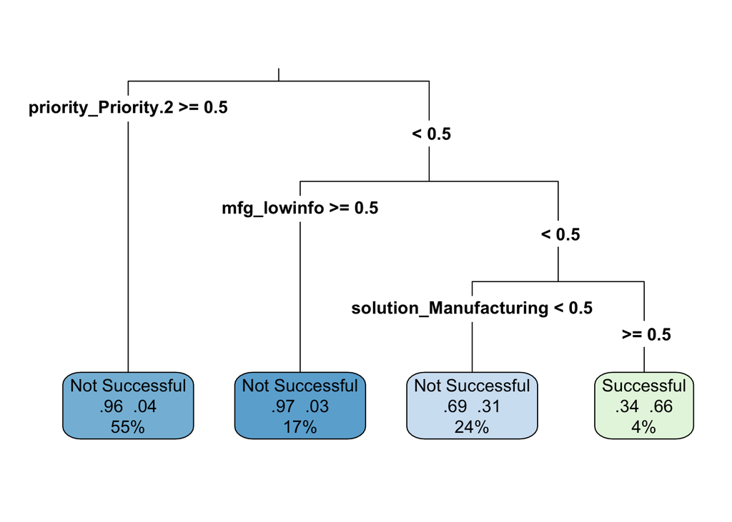

```r
# Create a simpler tree model for interpretation
simple_tree_model <- decision_tree(
  tree_depth = 3,
  min_n = 40
) %>%
  set_engine("rpart") %>%
  set_mode("classification")

# Build workflow
simple_tree_workflow <- workflow() %>%
  add_recipe(mx_recipe) %>%
  add_model(simple_tree_model)

# Fit simpler tree
simple_tree_fit <- fit(simple_tree_workflow, data = mx_training_data)

# Extract fitted tree
simple_tree_plot_fit <- extract_fit_parsnip(simple_tree_fit)$fit

# Plot simpler tree
rpart.plot(
  simple_tree_plot_fit,
  type = 3,
  extra = 104,
  fallen.leaves = TRUE,
  roundint = FALSE
)
```

#### Interpretation of the plot

This simplified decision tree shows the first few decision rules the model is using to separate stronger MX leads from weaker ones. The first split is based on `Priority 2`, which in the data dictionary refers to a more standard-priority lead rather than a higher-intent lead such as a demo request or contact-us inquiry. In simple terms, the model is first checking whether the lead looks more routine or more engaged. That makes business sense, because lead priority can reflect how ready the prospect may be to move forward.

The next important split is `mfg_lowinfo`, which shows whether the manufacturing model information is missing or low quality. This is consistent with the EDA findings, where incomplete enrichment was associated with weaker lead quality. After that, the tree uses `solution_Manufacturing`, which is a dummy variable created from the `solution` field. This does not refer to all MX leads overall. It specifically shows whether the lead is associated with the `Manufacturing` category inside that variable. In the strongest branch of this simplified tree, leads that are **not Priority 2**, have **better manufacturing information**, and are associated with **Manufacturing** end in the most favorable success node. Overall, the plot suggests that stronger MX leads are driven by a combination of **higher engagement**, **better enrichment quality**, and **better business fit**, rather than by only one variable.

#### What the Boxes in the Tree Mean

Each box in the tree is a final prediction group, and it gives three pieces of information:

- The **top line** shows the predicted class, such as **Successful** or **Not Successful**
- The **middle numbers** show the estimated probabilities for each class
  - for example, `.34 .66` means about **34% Not Successful** and **66% Successful**
- The **bottom percentage** shows the share of leads that fall into that box

So if a green box says **Successful / .34 .66 / 4%**, that means:

- the model predicts that group as **Successful**
- about **66% of leads in that group were successful**
- and that group represents **4%** of the data in the tree

#### What We Can Infer From This Plot

This plot suggests that the model is finding some practical screening rules for MX leads. Leads that appear more engaged, have more complete manufacturing-related information, and fit the manufacturing product context seem more promising. On the other hand, leads with **Priority 2** or **low-info manufacturing fields** move early into lower-success branches, which supports the EDA finding that weaker enrichment is a negative signal.

At the same time, this plot does **not** give a clean ranking of the exact best job titles. The tree is mainly showing the strongest top-level splits, and in this simplified version, title variables do not appear in the first few branches. That does not mean titles are unimportant. It only means that, in this tree, other variables were stronger early splitters. Because of that, this plot is most helpful for understanding business rules.